# Larval data analysis

```r
# Loading packages and data
library(ggplot2)
library(ecodata)
library(lubridate)
library(dplyr)
library(stringr)
library(marmap) # bathymetry
library(RColorBrewer)
library(ggnewscale)
library(sf)
library(cowplot)
library(tidyr)
library(raster)
# Larval data

larva <- read.csv(here::here('data/larval/Malacanthidae_all_lengthdata_Oct2023.csv'))
names(larva) <- tolower(names(larva))
larva <- larva %>%
    mutate(date = lubridate::dmy_hms(event_date),
      year = lubridate::year(date),
           month = lubridate::month(date),
           week = lubridate::week(date),
           day = lubridate::day(date)) %>%
  rename(cruise_id = cruise_name)

larva.w.zeros <- read.csv(here::here('data/larval/Malacanthidae_all_with0s_Oct2023.csv'))
names(larva.w.zeros) <- tolower(names(larva.w.zeros))
larva.w.zeros <- larva.w.zeros %>%
    mutate(date = lubridate::dmy_hms(event_date),
      year = lubridate::year(date),
           month = lubridate::month(date),
           week = lubridate::week(date),
           day = lubridate::day(date)) %>%
  rename(cruise_id = cruise_name)

# CTD data
ctd <- read.csv(here::here('data/larval/ctd_erddap_oct2023.csv'))
ctd_meta <- ctd[1,]
ctd <- ctd[-1,]
names(ctd) <- tolower(names(ctd))
ctd <- ctd %>%
    mutate(date = lubridate::ymd_hms(utc_date),
      year = lubridate::year(date),
           month = lubridate::month(date),
           week = lubridate::week(date),
           day = lubridate::day(date),
      depth = as.numeric(depth),
      pressure_dbars = as.numeric(pressure_dbars),
      sea_water_temperature = as.numeric(sea_water_temperature),
      sea_water_salinity = as.numeric(sea_water_salinity))

# loading in shape files
wd = here::here('shapefiles')
US.areas <- rgdal::readOGR(wd, 'USA', verbose = FALSE)
canada.areas <-rgdal::readOGR(wd,'Canada', verbose = FALSE)
US.areas <- US.areas %>% st_as_sf()
canada.areas <- canada.areas %>% st_as_sf()

bathy <- marmap::getNOAA.bathy(-81,-58, 27, 46)
bathy = fortify.bathy(bathy)

jet.colors <-colorRampPalette(c("blue", "#007FFF", "cyan","#7FFF7F", "yellow", "#FF7F00", "red", "#7F0000"))
```

### Initial exploration of larval data

Distribution of larval lengths. Yellow background indicates newly hatched larvae (freshies), orange indicates pelagic stage of larvae (pelagic) and grey background represents the size at which pelagic juveniles settle to the bottom (settlers).

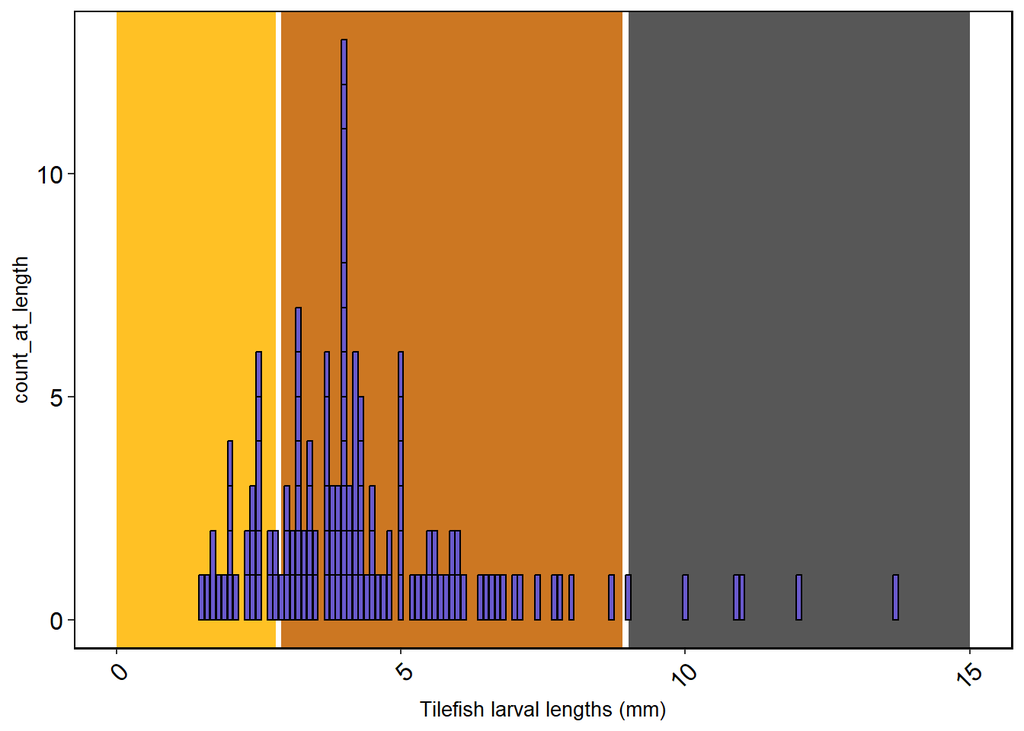

```r
#range(larva$length)
ggplot(larva,
       aes(x = length, y = count_at_length)) +
   geom_rect(aes(xmin = 0, xmax = 2.8, ymin = -Inf, ymax = Inf),
            fill = 'goldenrod1', alpha = 0.5) +
  geom_rect(aes(xmin = 2.9, xmax = 8.9, ymin = -Inf, ymax = Inf),
            fill = '#CC7722', alpha = 0.5) +
  geom_rect(aes(xmin = 9.0, xmax = 15, ymin = -Inf, ymax = Inf),
            fill = 'grey34', alpha = 0.5) +
   geom_bar(stat = 'identity',
           fill= 'slateblue', color="black") +
  xlab('Tilefish larval lengths (mm)') +
  xlim(0,15.0) +
  theme_bw() +
   theme(axis.text.x = element_text(color = 'black',
                                   size = 12, angle = 45, vjust = 1, hjust=1),
         axis.text.y = element_text(color = 'black',
                                   size = 12)) +
  theme_facet()
```

Range of years: 1977, 2022 Range of depth: 15, 3750

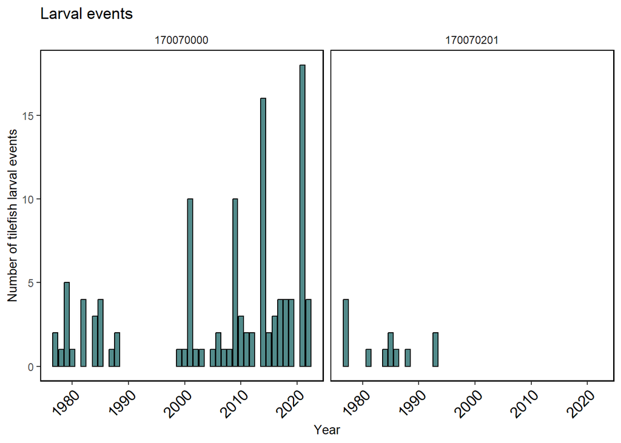

```r
ttl_larv <- larva %>%
  dplyr::select(total_count, year, event_number, taxa_ichthyo) %>%
  group_by(year, event_number, taxa_ichthyo) %>%
  summarise(n = sum(total_count))
ttl_larv2 <- ttl_larv %>%
  group_by(year, taxa_ichthyo) %>%
  summarise(ttl = sum(n))
ggplot(larva,
       aes(x = year)) +
  geom_bar(position = position_dodge(),
           fill= 'darkslategray4', color="black") +
  xlab('Year') +
  ylab('Number of tilefish larval events') +
  labs(title = 'Larval events') +
  facet_wrap(~taxa_ichthyo)+
   theme(axis.text.x = element_text(color = 'black',
                                   size = 12, angle = 45, vjust = 1, hjust=1)) +
  theme_facet()
```

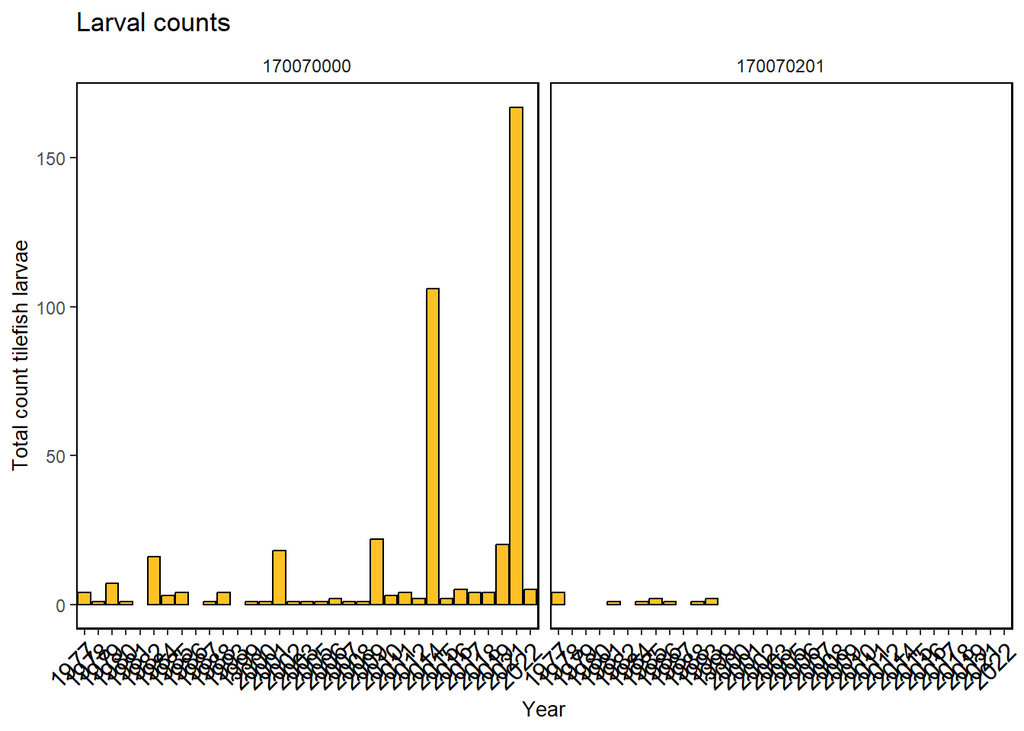

```r
ggplot(ttl_larv2,
       aes(x = factor(year), y = ttl)) +
  geom_bar(stat = 'identity', fill = 'goldenrod1', color = 'black') +
  xlab('Year') +
  ylab('Total count tilefish larvae') +
  labs(title = 'Larval counts') +
  facet_wrap(~taxa_ichthyo)+
   theme(axis.text.x = element_text(color = 'black',
                                   size = 12, angle = 45, vjust = 1, hjust=1)) +
  theme_facet()
```

Looking to see if/how the number of events at particular depth has a seasonal pattern

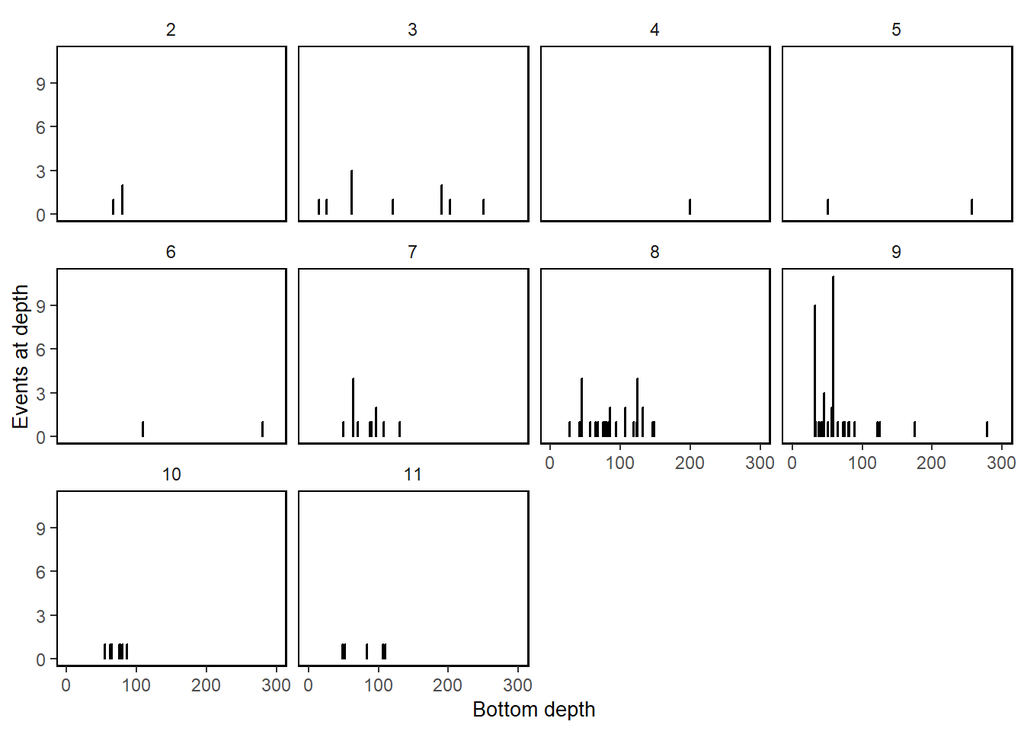

```r
# may be better represented as the proportion of events at each depth
# ggplot(larva,
#        aes(x = bottom_depth)) +
#   geom_bar(position = position_dodge(),
#            fill= 'blue4', color="black") +
#   xlab('Bottom depth') +
#   ylab('Events at depth') +
#   theme_facet()



# Looking to see if catch depth changes by month

lv.tally <- larva %>% # aggregate by year
  group_by(month, event_number, bottom_depth) %>%
  summarise(ttl_depth = length(bottom_depth),
            ttl_event = length(event_number))

ggplot(lv.tally,
       aes(x = bottom_depth, y = ttl_event)) +
  geom_bar(stat = 'identity', fill= 'blue4', color="black") +
  xlab('Bottom depth') +
  ylab('Events at depth') +
  xlim(0,300) +
  facet_wrap(~month) +
  theme_facet()
```

### Exploring spatial distribution of larval lengths

Larval lengths range from 1.5 to 28 Larval stages are binned according to lengths as indicated below, with the smallest larvae representing the newly hatched stage, the mid-size representing the pelagic stage and the largest larvae representing the stage at which they settle to the bottom.

- freshies <- length <= 2.8 (YELLOW CIRCLE)
- pelagic <- length <= 8.9 (ORANGE TRIANGLE)
- settlers <- length >= 9.0 (GREY SQUARE)

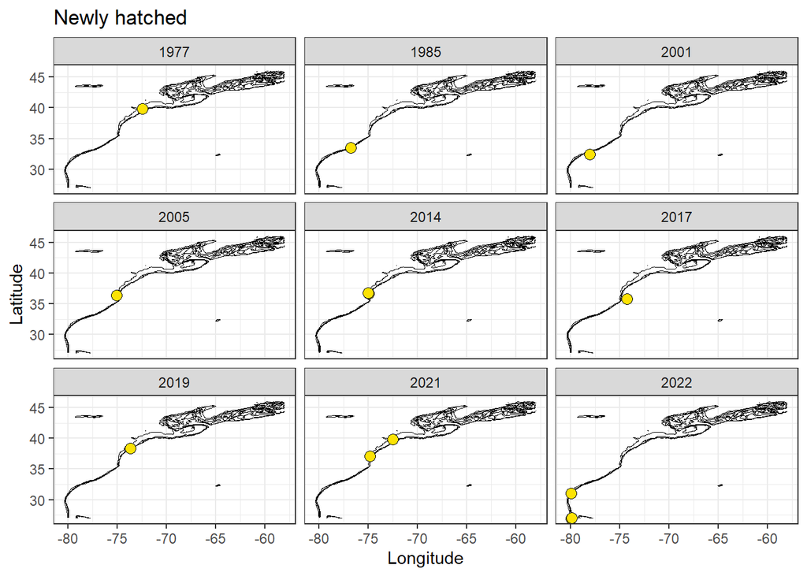

```r
freshies <- subset(larva, length <= 2.8)
pelagic <- subset(larva, length <= 8.99)
settlers <- subset(larva, length >= 9.0)

## Latitudinal range x size

# range(freshies$latitude)
# # 26.9800 39.8367
# range(pelagic$latitude)
# # 26.9800 41.0667
# range(settlers$latitude)
# # 32.388 41.160

## Longitudinal range x size

# range(freshies$longitude)
# # -79.920 -72.505
# range(pelagic$longitude)
# # -80.9000 -66.8083
# range(settlers$longitude)
# # -79.0007 -64.9900

### try to plot freshies vs pelagic vs settlers
ggplot(freshies, aes(x=longitude, y = latitude))+
geom_contour(data = bathy,
               aes(x=x,y=y,z=-1*z),
               breaks=c(50,100,150,200, Inf),
               size=c(0.3),
               col = 'black')+
  geom_point(pch = 21, bg = '#FCE205', col = 'black', size = 3) +
  labs(title = 'Newly hatched') +
  xlab('Longitude') +
  ylab('Latitude') +
  facet_wrap(~year) +
  theme_bw()
```

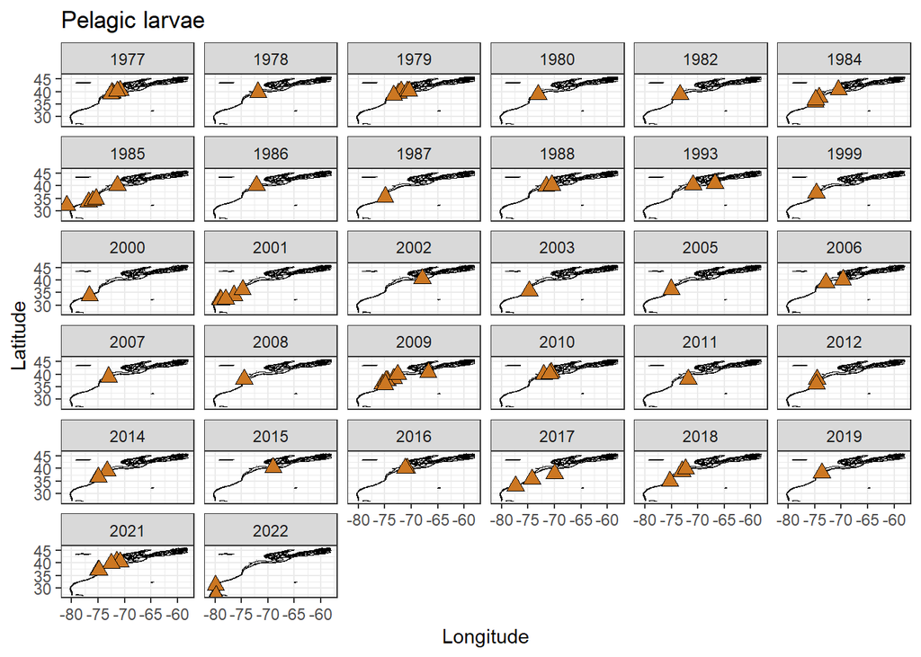

```r
ggplot(pelagic, aes(x=longitude, y = latitude))+
geom_contour(data = bathy,
               aes(x=x,y=y,z=-1*z),
               breaks=c(50,100,150,200, Inf),
               size=c(0.3),
               col = 'black')+
  geom_point(pch = 24, bg = '#CC7722', col = 'black', size = 3) +
  labs(title = 'Pelagic larvae') +
  xlab('Longitude') +
  ylab('Latitude') +
  facet_wrap(~year) +
  theme_bw()
```

[figure not shown]

```r
ggplot(freshies, aes(x=longitude, y = latitude))+
geom_contour(data = bathy,
               aes(x=x,y=y,z=-1*z),
               breaks=c(50,100,150,200, Inf),
               size=c(0.3),
               col = 'black')+
  geom_point(pch = 22, bg = 'grey34', col = 'black', size = 3) +
  labs(title = 'Settlers') +
  xlab('Longitude') +
  ylab('Latitude') +
  facet_wrap(~year) +
  theme_bw()
```

```r
# pch 21 = circle, 22 = square, 23 = diamond, 24 = triangle
# dijon = #C49102, ochre = #CC7722, honey = #FFC30B, bumblebee = #FCE205,
# sage= #759c8a, #738678, #cbdbcd
```

All larval lengths. Shape and color distinguish larval stage and possible location in the water column. First map is across all larval samples across all years. The second map is all samples by month.

- Freshies = Yellow circles,
- Pelagic = Orange triangles
- Settlers = Grey squares

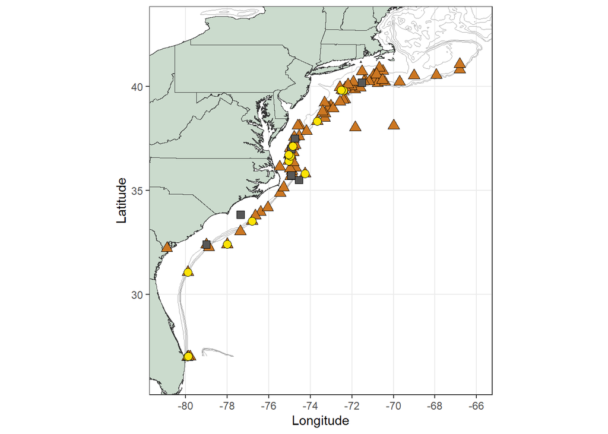

```r
ggplot() +
  geom_sf(data=US.areas %>% st_as_sf(),color = 'gray20', fill = '#cbdbcd') +
  geom_contour(data = bathy,
               aes(x=x,y=y,z=-1*z),
               breaks=c(50,100,150,200, Inf),
               size=c(0.3),
               col = 'darkgrey') +
  coord_sf(xlim = c(-81,-66.0), ylim = c(26,43), datum = sf::st_crs(4326))  +
  geom_point(data = pelagic, aes(x=longitude, y = latitude),
             pch = 24, bg = '#CC7722', color = 'black', size = 3) +
  geom_point(data = settlers, aes(x=longitude, y = latitude),
             pch = 22, bg = 'grey34', color = 'black', size = 3) +
  geom_point(data = freshies, aes(x=longitude, y = latitude),
             pch = 21, bg = '#FCE205', color = 'black', size = 3) +
  xlab('Longitude') +
  ylab('Latitude') +
  theme_bw()
```

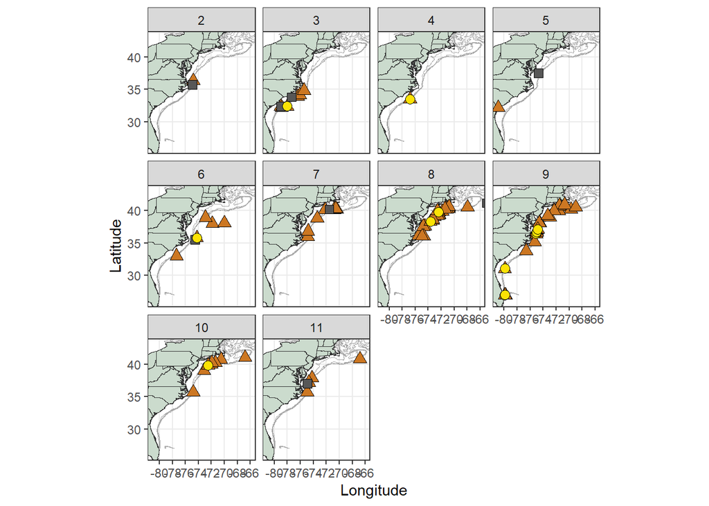

```r
ggplot() +
  geom_sf(data=US.areas %>% st_as_sf(),color = 'gray20', fill = '#cbdbcd') +
  geom_contour(data = bathy,
               aes(x=x,y=y,z=-1*z),
               breaks=c(50,100,150,200, Inf),
               size=c(0.3),
               col = 'darkgrey') +
  coord_sf(xlim = c(-81,-66.0), ylim = c(26,43), datum = sf::st_crs(4326))  +
  geom_point(data = pelagic, aes(x=longitude, y = latitude),
             pch = 24, bg = '#CC7722', color = 'black', size = 3) +
  geom_point(data = settlers, aes(x=longitude, y = latitude),
             pch = 22, bg = 'grey34', color = 'black', size = 3) +
  geom_point(data = freshies, aes(x=longitude, y = latitude),
             pch = 21, bg = '#FCE205', color = 'black', size = 3) +
  xlab('Longitude') +
  ylab('Latitude') +
  facet_wrap(~month) +
  theme_bw()
```

### Selecting CTD casts from larval events in 2021

```r
sst <- brick(here::here('data/sst/ww_sst_2021.tif'))
larvae.21 <- subset(larva, year == 2021)
events.21 <- data.frame(event_number = larvae.21$event_number,
                        week = larvae.21$week)
event.weeks <- sort(unique(larvae.21$week))
```

```r
ids.21 = unique(larvae.21$cruise_id)
ctd.21 = read.csv('ocdbs_v_erddap1_0a39_d12f_baca_2021.csv')
names(ctd.21) <- tolower(names(ctd.21))
ctd.21 = ctd.21 %>% filter(cruise_id %in% ids.21) %>%
    mutate(date = lubridate::ymd_hms(utc_date),
      # year = lubridate::year(date),
      #      month = lubridate::month(date),
      #      week = lubridate::week(date),
      #      day = lubridate::day(date),
      depth = as.numeric(depth),
      pressure_dbars = as.numeric(pressure_dbars),
      sea_water_temperature = as.numeric(sea_water_temperature),
      sea_water_salinity = as.numeric(sea_water_salinity)) %>%
  dplyr::select(date,cruise_id, cast_number,purpose_code,
                latitude, longitude,
                pressure_dbars, sea_water_temperature, sea_water_salinity) %>%
  na.omit()
```

Cruise HB2103 had 202 unique CTD casts. Larvae were found at 3 locations for this cruise. The following plots are the paired CTD casts (12,10,67) at the locations where there were larval events.

#### Event 37: (37.0367, -74.9733), Week 37 2021

Station 3291, plankton stratum 5, bottom depth:46

- Total_count = 3
- Count_at_length = 1
- Lengths = 5.5, 5.8, 6.4 (pelagic)

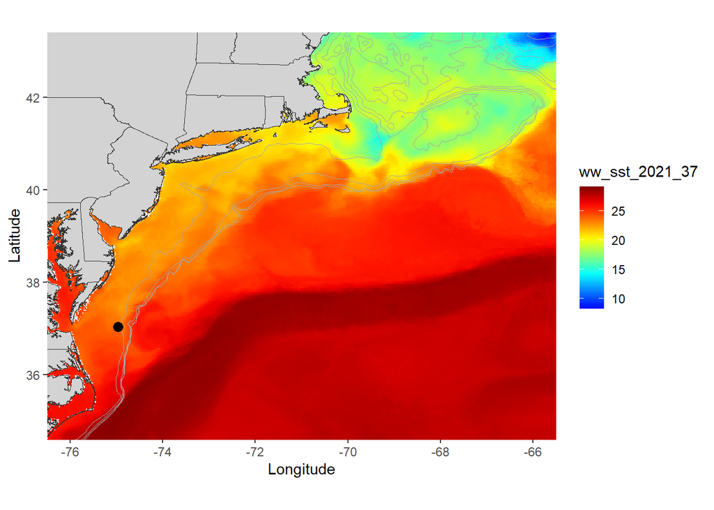

```r
b = sst[[37]]
df <- raster::as.data.frame(b, xy=TRUE) %>% drop_na()
ggplot() +
  geom_tile(data = df, aes(x=x, y=y, fill = ww_sst_2021_37)) +
  scale_fill_gradientn(colours = jet.colors(25)) +
  geom_sf(data=US.areas %>% st_as_sf(),color = 'gray20', fill = 'lightgrey') +
   geom_contour(data = bathy,
               aes(x=x,y=y,z=-1*z),
               breaks=c(50,100,150,200, Inf),
               size=c(0.3),
               col = 'darkgrey') +
  geom_point(data = larvae.21 %>% filter(week == 37 & event_number == 37),
             aes(x=longitude, y = latitude), size = 3) +
  # coord_sf(xlim = c(-81,-66.0), ylim = c(26,43), datum = sf::st_crs(4326))  +
  coord_sf(xlim = c(-76,-66.0), ylim = c(35,43), datum = sf::st_crs(4326)) +
  xlab('Longitude') +
  ylab('Latitude')
```

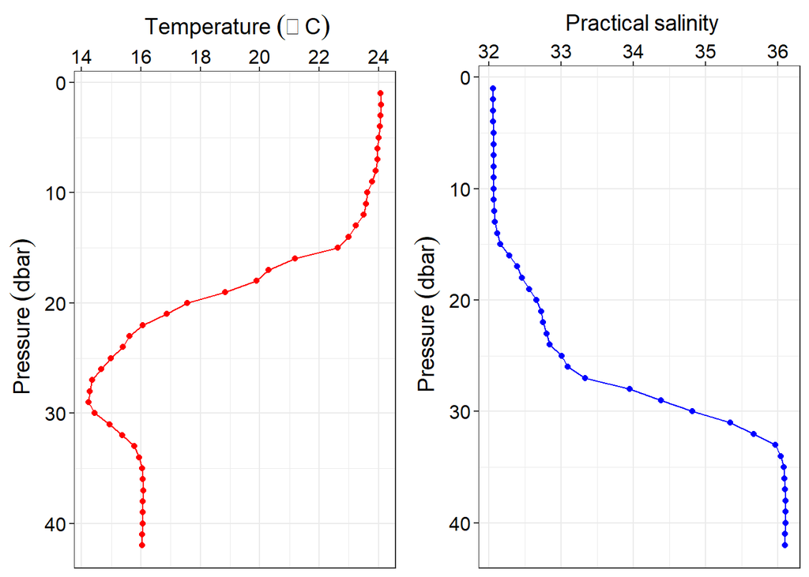

```r
HB2103 <- subset(ctd.21, cruise_id == 'HB2103')
#`r length(unique(HB2103$cast_number))`
coords <- which(HB2103$latitude == 37.0367 & HB2103$longitude == -74.9733)
HB2103.event37 = HB2103[coords,]
# event 37, total_count = 3, count_at_length = 1, lengths = 5.5, 5.8, 6.4

# ** Note there are two event 37s, and the coordinates below do not match any
# for the trip ID HB2103
# coords <- which(HB2103$latitude == 40.5000 & HB2103$longitude == -70.8283)
# HB2103.event37.2 = HB2103[coords,]

## EVENT 37.1
temp = ggplot(HB2103.event37,
              aes(x = (sea_water_temperature),
                  y = (pressure_dbars))) +
  geom_point(color = 'red') +
  geom_path(col = 'red') +
  scale_x_continuous(position = "top") +
  scale_y_reverse() +
  theme_bw() +
  theme(axis.text = element_text(size = 12, colour = 1),
        axis.title = element_text(size = 14, colour = 1))+
  labs(x = expression(~Temperature~(degree~C)),
       y = expression(~Pressure~(dbar))) #title = 'HB2103.event37'
sal =  ggplot(HB2103.event37,
              aes(x = (sea_water_salinity),
                  y = (pressure_dbars))) +
  geom_point(color = 'blue') +
  geom_path(col = 'blue') +
  scale_x_continuous(position = "top")+
  scale_y_reverse() +
  theme_bw() +
  theme(axis.text = element_text(size = 12, colour = 1),
        axis.title = element_text(size = 14, colour = 1))+
  labs(x = expression(~Practical~salinity),
       y = expression(~Pressure~(dbar)))

cowplot::plot_grid(temp,sal, nrow = 1)
```

#### Event 35 (37.1183, -74.8417), week 37 2021

**Station 3007, plankton stratum 5, bottom_depth:59**

- Total_count = says 14, only 12 values
- Count_at_length = 1
- Lengths = 1.5, 1.6, 1.7(x2), 1.8, 2.0, 2.1, 2.3, 2.5, 2.8, 3.0, 4.3
- 10 freshies, 2 pelagic

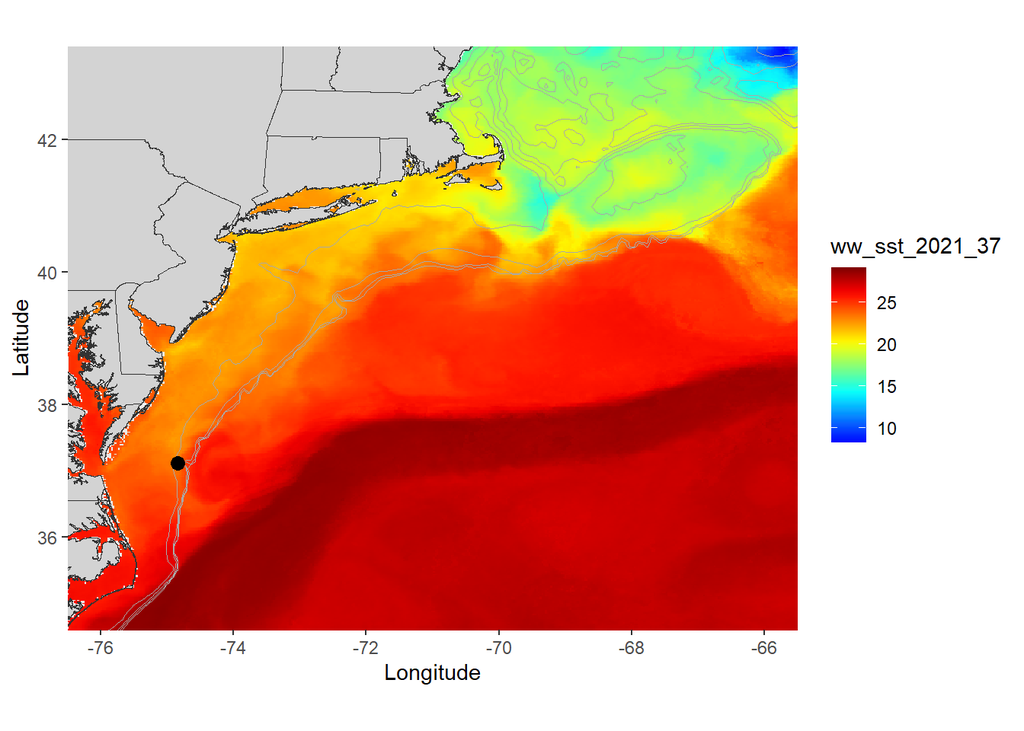

```r
b = sst[[37]]
df <- raster::as.data.frame(b, xy=TRUE) %>% drop_na()
ggplot() +
  geom_tile(data = df, aes(x=x, y=y, fill = ww_sst_2021_37)) +
  scale_fill_gradientn(colours = jet.colors(25)) +
  geom_sf(data=US.areas %>% st_as_sf(),color = 'gray20', fill = 'lightgrey') +
   geom_contour(data = bathy,
               aes(x=x,y=y,z=-1*z),
               breaks=c(50,100,150,200, Inf),
               size=c(0.3),
               col = 'darkgrey') +
  geom_point(data = larvae.21 %>% filter(week == 37 & event_number == 35),
             aes(x=longitude, y = latitude), size = 3) +
  # coord_sf(xlim = c(-81,-66.0), ylim = c(26,43), datum = sf::st_crs(4326))  +
  coord_sf(xlim = c(-76,-66.0), ylim = c(35,43), datum = sf::st_crs(4326)) +
  xlab('Longitude') +
  ylab('Latitude')
```

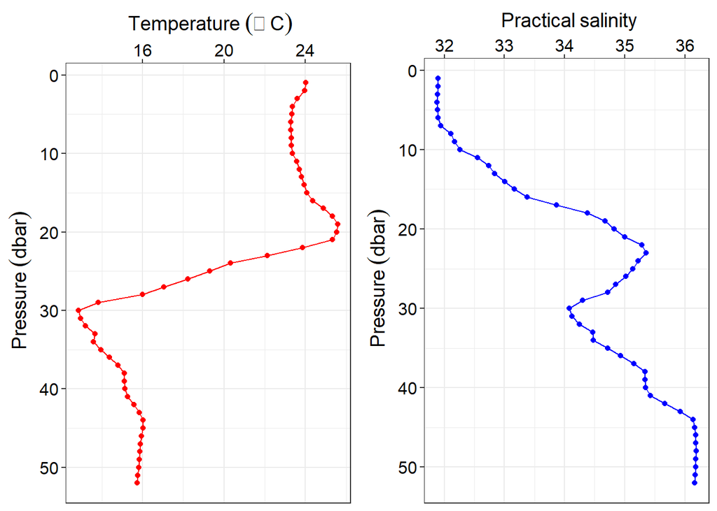

```r
HB2103 <- subset(ctd.21, cruise_id == 'HB2103')
e35 <- subset(larvae.21, event_number == 35)
e35 <- sort(unique(e35$length))
# lat lon 37.1183 -74.8417

coords <- which(HB2103$latitude == 37.1183 & HB2103$longitude == -74.8417)
HB2103.event35 = HB2103[coords,]

temp = ggplot(HB2103.event35,
              aes(x = (sea_water_temperature),
                  y = (pressure_dbars))) +
  geom_point(color = 'red') +
  geom_path(col = 'red') +
  scale_x_continuous(position = "top") +
  scale_y_reverse() +
  theme_bw() +
  theme(axis.text = element_text(size = 12, colour = 1),
        axis.title = element_text(size = 14, colour = 1))+
  labs(x = expression(~Temperature~(degree~C)),
       y = expression(~Pressure~(dbar)))
sal =  ggplot(HB2103.event35,
              aes(x = (sea_water_salinity),
                  y = (pressure_dbars))) +
  geom_point(color = 'blue') +
  geom_path(col = 'blue') +
  scale_x_continuous(position = "top")+
  scale_y_reverse() +
  theme_bw() +
  theme(axis.text = element_text(size = 12, colour = 1),
        axis.title = element_text(size = 14, colour = 1))+
  labs(x = expression(~Practical~salinity),
       y = expression(~Pressure~(dbar)))

cowplot::plot_grid(temp,sal, nrow = 1)
```

#### Event 185 (40.7333, -71.5183), Week 39, 2021

**Station 3318, plankton stratum 19, bottom_depth:65**

- Total_count = 1
- Count_at_length = 1
- Lengths = 7.8, pelagic

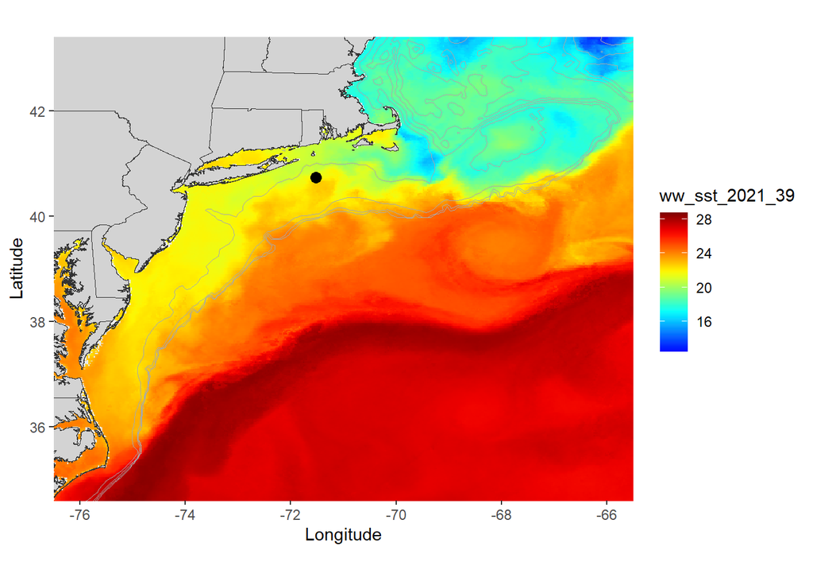

```r
b = sst[[39]]
df <- raster::as.data.frame(b, xy=TRUE) %>% drop_na()
ggplot() +
  geom_tile(data = df, aes(x=x, y=y, fill = ww_sst_2021_39)) +
  scale_fill_gradientn(colours = jet.colors(25)) +
  geom_sf(data=US.areas %>% st_as_sf(),color = 'gray20', fill = 'lightgrey') +
   geom_contour(data = bathy,
               aes(x=x,y=y,z=-1*z),
               breaks=c(50,100,150,200, Inf),
               size=c(0.3),
               col = 'darkgrey') +
  geom_point(data = larvae.21 %>% filter(week == 39 & event_number == 185),
             aes(x=longitude, y = latitude), size = 3) +
  # coord_sf(xlim = c(-81,-66.0), ylim = c(26,43), datum = sf::st_crs(4326))  +
  coord_sf(xlim = c(-76,-66.0), ylim = c(35,43), datum = sf::st_crs(4326)) +
  xlab('Longitude') +
  ylab('Latitude')
```

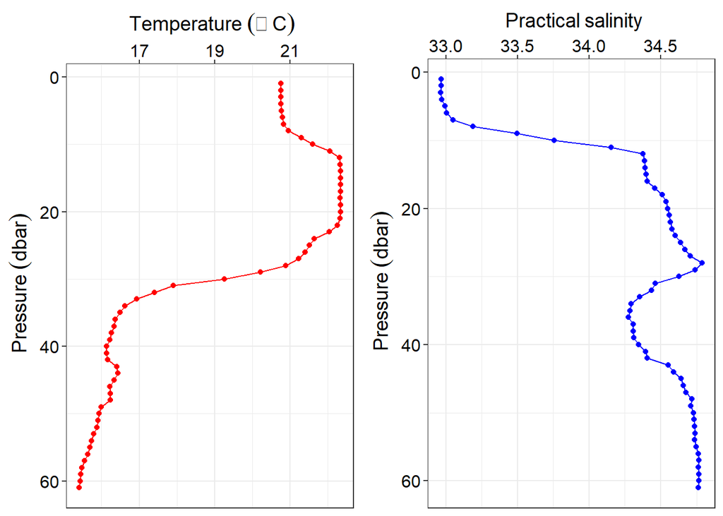

```r
HB2103 <- subset(ctd.21, cruise_id == 'HB2103')
e185 <- subset(larvae.21, event_number == 185)
e185 <- sort(unique(e185$length))
# lat lon 37.1183 -74.8417

coords <- which(HB2103$latitude == 40.7333 & HB2103$longitude == -71.5183)
HB2103.event185 = HB2103[coords,]

temp = ggplot(HB2103.event185,
              aes(x = (sea_water_temperature),
                  y = (pressure_dbars))) +
  geom_point(color = 'red') +
  geom_path(col = 'red') +
  scale_x_continuous(position = "top") +
  scale_y_reverse() +
  theme_bw() +
  theme(axis.text = element_text(size = 12, colour = 1),
        axis.title = element_text(size = 14, colour = 1))+
  labs(x = expression(~Temperature~(degree~C)),
       y = expression(~Pressure~(dbar)))
sal =  ggplot(HB2103.event185,
              aes(x = (sea_water_salinity),
                  y = (pressure_dbars))) +
  geom_point(color = 'blue') +
  geom_path(col = 'blue') +
  scale_x_continuous(position = "top")+
  scale_y_reverse() +
  theme_bw() +
  theme(axis.text = element_text(size = 12, colour = 1),
        axis.title = element_text(size = 14, colour = 1))+
  labs(x = expression(~Practical~salinity),
       y = expression(~Pressure~(dbar)))

cowplot::plot_grid(temp,sal, nrow = 1)
```

#### Event 215 (41.1600,-64.9900), Week 32 2021

**Station 171, plankton stratum NA, bottom depth 3401**

- Total_count = 1
- Count_at_length = 1
- Lengths = 13.7, settler

** NOTE there is not a ctd cast for this cruise_id (HB2102)

```r
b = sst[[32]]
df <- raster::as.data.frame(b, xy=TRUE) %>% drop_na()
ggplot() +
  geom_tile(data = df, aes(x=x, y=y, fill = ww_sst_2021_32)) +
  scale_fill_gradientn(colours = jet.colors(25)) +
  geom_sf(data=US.areas %>% st_as_sf(),color = 'gray20', fill = 'lightgrey') +
   geom_contour(data = bathy,
               aes(x=x,y=y,z=-1*z),
               breaks=c(50,100,150,200, Inf),
               size=c(0.3),
               col = 'darkgrey') +
  geom_point(data = larvae.21 %>% filter(week == 32 & event_number == 215),
             aes(x=longitude, y = latitude), size = 3) +
  # coord_sf(xlim = c(-81,-66.0), ylim = c(26,43), datum = sf::st_crs(4326))  +
  coord_sf(xlim = c(-76,-66.0), ylim = c(35,43), datum = sf::st_crs(4326)) +
  xlab('Longitude') +
  ylab('Latitude')

HB2102 <- subset(ctd.21, cruise_id == 'HB2102')
e215 <- subset(larvae.21, event_number == 215)
e215 <- sort(unique(e215$length))
# lat lon 37.1183 -74.8417

coords <- which(HB2102$latitude == 41.1600 & HB2102$longitude == -64.9900)
HB2102.event215 = HB2102[coords,]

temp = ggplot(HB2102.event215,
              aes(x = (sea_water_temperature),
                  y = (pressure_dbars))) +
  geom_point(color = 'red') +
  geom_path(col = 'red') +
  scale_x_continuous(position = "top") +
  scale_y_reverse() +
  theme_bw() +
  theme(axis.text = element_text(size = 12, colour = 1),
        axis.title = element_text(size = 14, colour = 1))+
  labs(x = expression(~Temperature~(degree~C)),
       y = expression(~Pressure~(dbar)))
sal =  ggplot(HB2102.event215,
              aes(x = (sea_water_salinity),
                  y = (pressure_dbars))) +
  geom_point(color = 'blue') +
  geom_path(col = 'blue') +
  scale_x_continuous(position = "top")+
  scale_y_reverse() +
  theme_bw() +
  theme(axis.text = element_text(size = 12, colour = 1),
        axis.title = element_text(size = 14, colour = 1))+
  labs(x = expression(~Practical~salinity),
       y = expression(~Pressure~(dbar)))

cowplot::plot_grid(temp,sal, nrow = 1)
```

[output not shown]

**Station 10, plankton stratum 15, bottom depth 65**

- Total_count = 1
- Count_at_length = 1
- Lengths = 2.5, freshie

```r
b = sst[[42]]
df <- raster::as.data.frame(b, xy=TRUE) %>% drop_na()
ggplot() +
  geom_tile(data = df, aes(x=x, y=y, fill = ww_sst_2021_42)) +
  scale_fill_gradientn(colours = jet.colors(25)) +
  geom_sf(data=US.areas %>% st_as_sf(),color = 'gray20', fill = 'lightgrey') +
   geom_contour(data = bathy,
               aes(x=x,y=y,z=-1*z),
               breaks=c(50,100,150,200, Inf),
               size=c(0.3),
               col = 'darkgrey') +
  geom_point(data = larvae.21 %>% filter(week == 42 & event_number == 10),
             aes(x=longitude, y = latitude), size = 3) +
  # coord_sf(xlim = c(-81,-66.0), ylim = c(26,43), datum = sf::st_crs(4326))  +
  coord_sf(xlim = c(-76,-66.0), ylim = c(35,43), datum = sf::st_crs(4326)) +
  xlab('Longitude') +
  ylab('Latitude')

PC2106 <- subset(ctd.21, cruise_id == 'PC2106')
e10 <- subset(larvae.21, event_number == 10)
e10 <- sort(unique(e10$length))
# lat lon 37.1183 -74.8417

coords <- which(PC2106$latitude == 39.8367 & PC2106$longitude == -72.5050)
PC2106.event10 = PC2106[coords,]

temp = ggplot(PC2106.event10,
              aes(x = (sea_water_temperature),
                  y = (pressure_dbars))) +
  geom_point(color = 'red') +
  geom_path(col = 'red') +
  scale_x_continuous(position = "top") +
  scale_y_reverse() +
  theme_bw() +
  theme(axis.text = element_text(size = 12, colour = 1),
        axis.title = element_text(size = 14, colour = 1))+
  labs(x = expression(~Temperature~(degree~C)),
       y = expression(~Pressure~(dbar)))
sal =  ggplot(PC2106.event10,
              aes(x = (sea_water_salinity),
                  y = (pressure_dbars))) +
  geom_point(color = 'blue') +
  geom_path(col = 'blue') +
  scale_x_continuous(position = "top")+
  scale_y_reverse() +
  theme_bw() +
  theme(axis.text = element_text(size = 12, colour = 1),
        axis.title = element_text(size = 14, colour = 1))+
  labs(x = expression(~Practical~salinity),
       y = expression(~Pressure~(dbar)))

cowplot::plot_grid(temp,sal, nrow = 1)
```

[output not shown]

### CTD Casts w/out larval events 2021

#### CTD Cast 48 (40.3033, -72.2967)

Exploring a location without a larval event

Purpose code 10

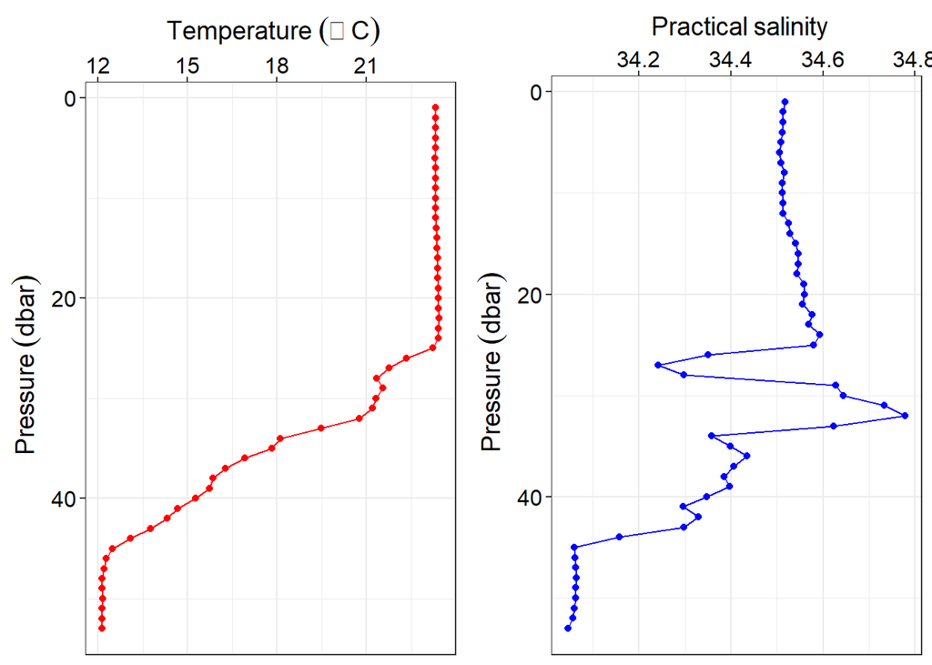

```r
HB2103 <- subset(ctd.21, cruise_id == 'HB2103')
# b = sst[[39]]
# df <- raster::as.data.frame(b, xy=TRUE) %>% drop_na()
# ggplot() +
#   geom_tile(data = df, aes(x=x, y=y, fill = ww_sst_2021_39)) +
#   scale_fill_gradientn(colours = jet.colors(25)) +
#   new_scale_fill() +
#   geom_sf(data=US.areas %>% st_as_sf(),color = 'gray20', fill = 'lightgrey') +
#   geom_contour(data = bathy,
#                aes(x=x,y=y,z=-1*z),
#                breaks=c(50,100,150,200, Inf),
#                size=c(0.3),
#                col = 'darkgrey') +
#   geom_point(data = HB2103 %>% filter(cast_number == 48 & purpose_code == 10),
#              aes(x=longitude, y = latitude), size = 3) +
#   coord_sf(xlim = c(-81,-66.0), ylim = c(26,43), datum = sf::st_crs(4326))  +
#   coord_sf(xlim = c(-76,-66.0), ylim = c(35,43), datum = sf::st_crs(4326)) +
#   xlab('Longitude') +
#   ylab('Latitude')


# lat lon 37.1183 -74.8417

coords <- which(HB2103$latitude == 40.3033 & HB2103$longitude == -72.2967)
HB2103.c48 = HB2103[coords,]
HB2103.c48.p <- HB2103.c48[1,]
temp = ggplot(HB2103.c48,
              aes(x = (sea_water_temperature),
                  y = (pressure_dbars))) +
  geom_point(color = 'red') +
  geom_path(col = 'red') +
  scale_x_continuous(position = "top") +
  scale_y_reverse() +
  theme_bw() +
  theme(axis.text = element_text(size = 12, colour = 1),
        axis.title = element_text(size = 14, colour = 1))+
  labs(x = expression(~Temperature~(degree~C)),
       y = expression(~Pressure~(dbar)))
sal =  ggplot(HB2103.c48,
              aes(x = (sea_water_salinity),
                  y = (pressure_dbars))) +
  geom_point(color = 'blue') +
  geom_path(col = 'blue') +
  scale_x_continuous(position = "top")+
  scale_y_reverse() +
  theme_bw() +
  theme(axis.text = element_text(size = 12, colour = 1),
        axis.title = element_text(size = 14, colour = 1))+
  labs(x = expression(~Practical~salinity),
       y = expression(~Pressure~(dbar)))

cowplot::plot_grid(temp,sal, nrow = 1)
```

#### CTD Cast 2 (39.2133,-73.3317)

Exploring a location without a larval event

Purpose code 10

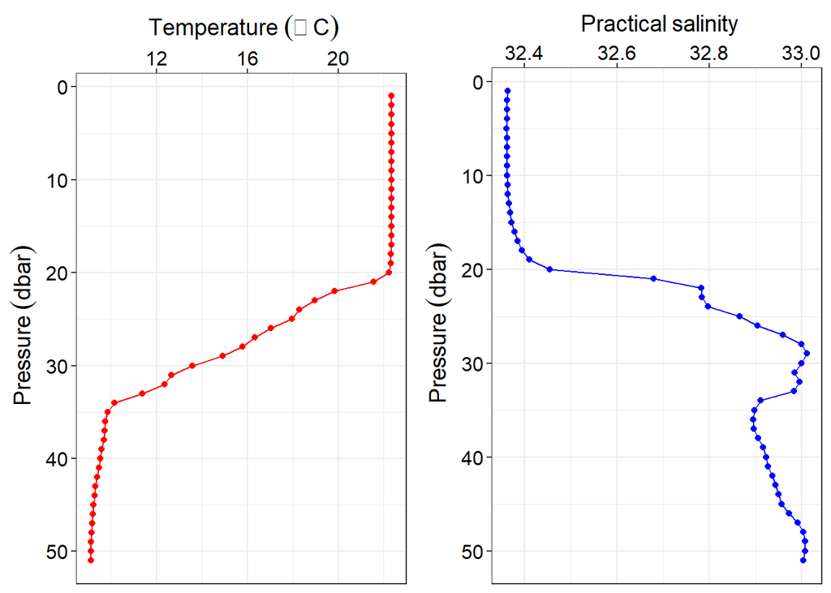

```r
HB2103 <- subset(ctd.21, cruise_id == 'HB2103')
larv.cruise.id.21 <- sort(unique(larvae.21$cruise_id))
# lat lon 37.1183 -74.8417
cruise.id.21 <- sort(unique(ctd.21$cruise_id))

coords <- which(HB2103$latitude == 39.2133 & HB2103$longitude == -73.3317)
HB2103.c2 = HB2103[coords,]

temp = ggplot(HB2103.c2,
              aes(x = (sea_water_temperature),
                  y = (pressure_dbars))) +
  geom_point(color = 'red') +
  geom_path(col = 'red') +
  scale_x_continuous(position = "top") +
  scale_y_reverse() +
  theme_bw() +
  theme(axis.text = element_text(size = 12, colour = 1),
        axis.title = element_text(size = 14, colour = 1))+
  labs(x = expression(~Temperature~(degree~C)),
       y = expression(~Pressure~(dbar)))
sal =  ggplot(HB2103.c2,
              aes(x = (sea_water_salinity),
                  y = (pressure_dbars))) +
  geom_point(color = 'blue') +
  geom_path(col = 'blue') +
  scale_x_continuous(position = "top")+
  scale_y_reverse() +
  theme_bw() +
  theme(axis.text = element_text(size = 12, colour = 1),
        axis.title = element_text(size = 14, colour = 1))+
  labs(x = expression(~Practical~salinity),
       y = expression(~Pressure~(dbar)))

cowplot::plot_grid(temp,sal, nrow = 1)
```

### CTD Casts w/out larval events 1990s

#### 1993 CTD Cast 178 (41.6233, -69.2467)

Exploring a location without a larval event (1993)

Cruise id = ALB9304, Cast 178 Bottom depth 178, gear type = SBE-19

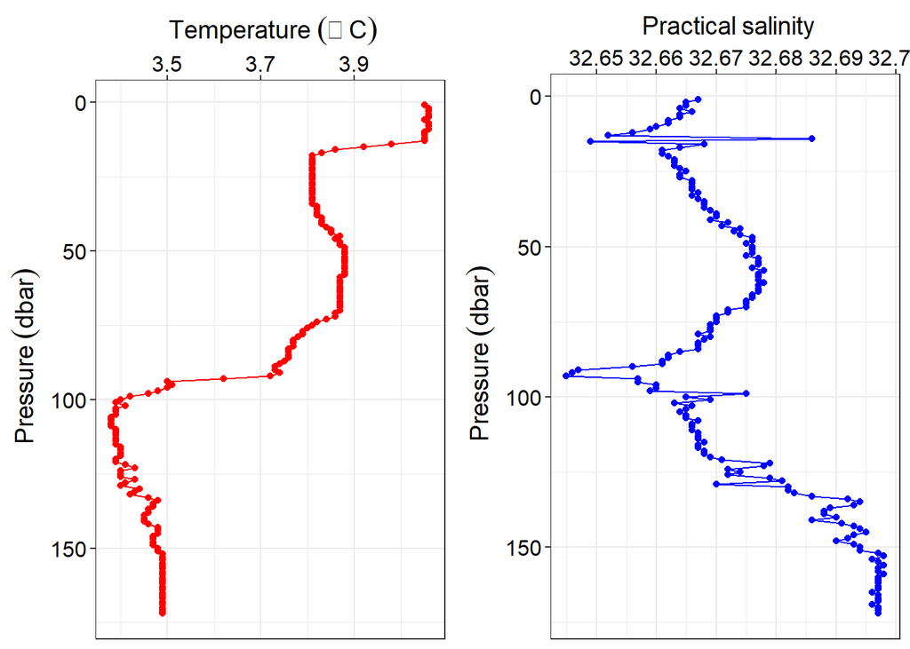

```r
ctd.93 <- subset(ctd, year == 1993)
ALB9304 <- subset(ctd.93, cruise_id == 'ALB9304')
larv.93 <-subset(larva, year == 1993)
# sort(unique(larv.93$cruise_id))
# Larval events
ev.1591 <- subset(larv.93, cruise_id == "DE9311") # 40.5500, -70.9500, length 3.9

ev.2361 <- subset(larv.93, cruise_id == "DE9311")# 41.0667, -66.8167, length 5.5


coords <- which(ALB9304$latitude == 41.6233 & ALB9304$longitude == -69.2467)
ALB9304.c178 = ALB9304[coords,]

temp = ggplot(ALB9304.c178,
              aes(x = (sea_water_temperature),
  y = (pressure_dbars))) +
  geom_point(color = 'red') +
  geom_path(col = 'red') +
  scale_x_continuous(position = "top") +
  scale_y_reverse() +
  theme_bw() +
  theme(axis.text = element_text(size = 12, colour = 1),
        axis.title = element_text(size = 14, colour = 1))+
  labs(x = expression(~Temperature~(degree~C)),
       y = expression(~Pressure~(dbar)))
sal =  ggplot(ALB9304.c178,
              aes(x = (sea_water_salinity),
  y = (pressure_dbars))) +
  geom_point(color = 'blue') +
  geom_path(col = 'blue') +
  scale_x_continuous(position = "top")+
  scale_y_reverse() +
  theme_bw() +
  theme(axis.text = element_text(size = 12, colour = 1),
        axis.title = element_text(size = 14, colour = 1))+
  labs(x = expression(~Practical~salinity),
        y = expression(~Pressure~(dbar)))

cowplot::plot_grid(temp,sal, nrow = 1)
```

#### 1993 CTD Cast 14 (42.6067, -68.2833)

Exploring a location without a larval event (1993)

Cruise id = DEL9308, Cast 14 Bottom depth 184, gear type = SBE-19

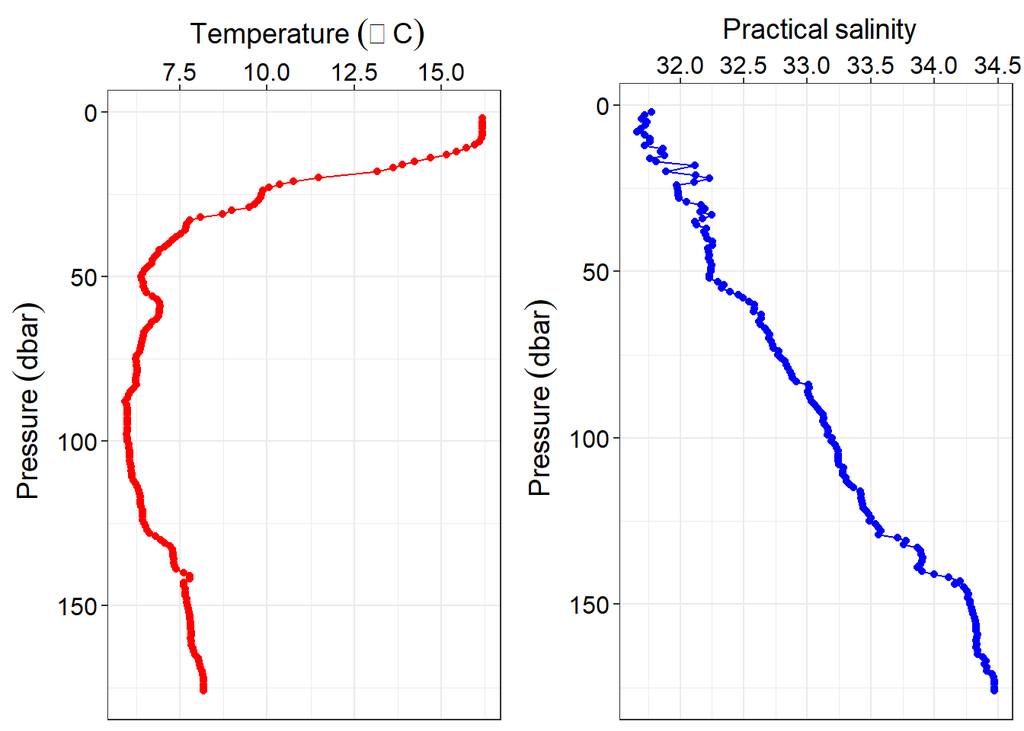

```r
DEL9308 <- subset(ctd.93, cruise_id == 'DEL9308')
coords <- which(DEL9308$latitude == 42.6067 & DEL9308$longitude == -68.2833)
DEL9308.c14 = DEL9308[coords,]

temp = ggplot(DEL9308.c14,
              aes(x = (sea_water_temperature),
  y = (pressure_dbars))) +
  geom_point(color = 'red') +
  geom_path(col = 'red') +
  scale_x_continuous(position = "top") +
  scale_y_reverse() +
  theme_bw() +
  theme(axis.text = element_text(size = 12, colour = 1),
        axis.title = element_text(size = 14, colour = 1))+
  labs(x = expression(~Temperature~(degree~C)),
       y = expression(~Pressure~(dbar)))
sal =  ggplot(DEL9308.c14,
              aes(x = (sea_water_salinity),
  y = (pressure_dbars))) +
  geom_point(color = 'blue') +
  geom_path(col = 'blue') +
  scale_x_continuous(position = "top")+
  scale_y_reverse() +
  theme_bw() +
  theme(axis.text = element_text(size = 12, colour = 1),
        axis.title = element_text(size = 14, colour = 1))+
  labs(x = expression(~Practical~salinity),
        y = expression(~Pressure~(dbar)))

cowplot::plot_grid(temp,sal, nrow = 1)
```

#### 1993 CTD Cast 270 (42.9,-67.4133)

Exploring a location without a larval event (1993)

Cruise id = DEL9311, Cast 270 Bottom depth 260, gear type = SBE-19

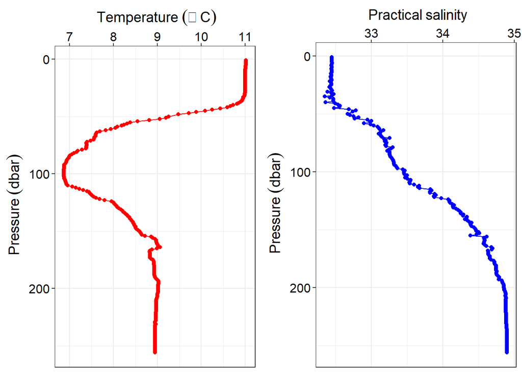

```r
DEL9311 <- subset(ctd.93, cruise_id == 'DEL9311')
coords <- which(DEL9311$latitude == 42.9 & DEL9311$longitude == -67.4133)
DEL9311.c270 = DEL9311[coords,]

temp = ggplot(DEL9311.c270,
              aes(x = (sea_water_temperature),
  y = (pressure_dbars))) +
  geom_point(color = 'red') +
  geom_path(col = 'red') +
  scale_x_continuous(position = "top") +
  scale_y_reverse() +
  theme_bw() +
  theme(axis.text = element_text(size = 12, colour = 1),
        axis.title = element_text(size = 14, colour = 1))+
  labs(x = expression(~Temperature~(degree~C)),
       y = expression(~Pressure~(dbar)))
sal =  ggplot(DEL9311.c270,
              aes(x = (sea_water_salinity),
  y = (pressure_dbars))) +
  geom_point(color = 'blue') +
  geom_path(col = 'blue') +
  scale_x_continuous(position = "top")+
  scale_y_reverse() +
  theme_bw() +
  theme(axis.text = element_text(size = 12, colour = 1),
        axis.title = element_text(size = 14, colour = 1))+
  labs(x = expression(~Practical~salinity),
        y = expression(~Pressure~(dbar)))

cowplot::plot_grid(temp,sal, nrow = 1)
```

```r
##### CTD Casts with larval events 1990s
# This is the other type of larvae

###### 1993 Event 1591 (40.5500, -70.9500)

# Exploring a location with a larval event (1993)
#
# Cruise id = DE9311, Cast 178
# Bottom depth 73, gear type = SBE-19

ctd.93 <- subset(ctd, year == 1993)
DE9311 <- subset(ctd.93, cruise_id == 'DEL9311')
larv.93 <-subset(larva, year == 1993)
# sort(unique(larv.93$cruise_id))
sort(unique(ctd.93$cruise_id))
# Larval events
ev.1591 <- subset(larv.93, cruise_id == "DE9311") # 40.5500, -70.9500, length 3.9

ev.2361 <- subset(larv.93, cruise_id == "DE9311")# 41.0667, -66.8167, length 5.5


coords <- which(ALB9304$latitude == 41.6233 & ALB9304$longitude == -69.2467)
ALB9304.c178 = ALB9304[coords,]

temp = ggplot(ALB9304.c178,
              aes(x = (sea_water_temperature),
  y = (pressure_dbars))) +
  geom_point(color = 'red') +
  geom_path(col = 'red') +
  scale_x_continuous(position = "top") +
  scale_y_reverse() +
  theme_bw() +
  theme(axis.text = element_text(size = 12, colour = 1),
        axis.title = element_text(size = 14, colour = 1))+
  labs(x = expression(~Temperature~(degree~C)),
       y = expression(~Pressure~(dbar)))
sal =  ggplot(ALB9304.c178,
              aes(x = (sea_water_salinity),
  y = (pressure_dbars))) +
  geom_point(color = 'blue') +
  geom_path(col = 'blue') +
  scale_x_continuous(position = "top")+
  scale_y_reverse() +
  theme_bw() +
  theme(axis.text = element_text(size = 12, colour = 1),
        axis.title = element_text(size = 14, colour = 1))+
  labs(x = expression(~Practical~salinity),
        y = expression(~Pressure~(dbar)))

cowplot::plot_grid(temp,sal, nrow = 1)
```

### CTD Casts w/out larval events 1980s

#### CTD Cast 3 (35.4667, -75.25)

Exploring a location without a larval event (1980)

Cruise id = EVR8001, Cast 3 Bottom depth 29, gear type = bottle

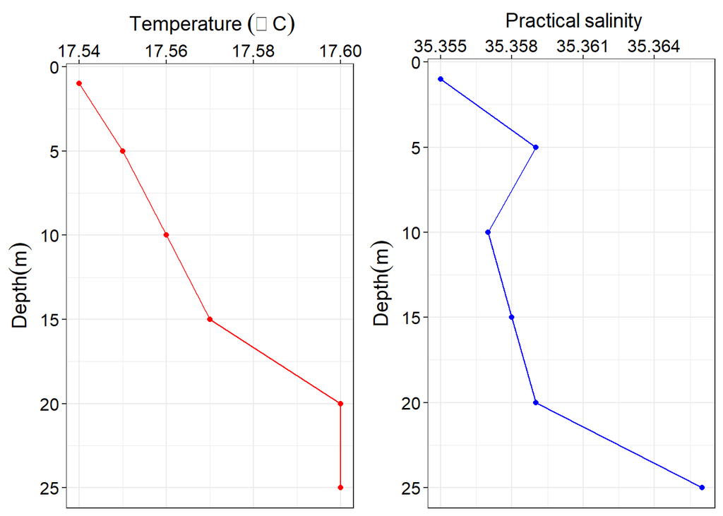

```r
# sort(unique(ctd$year))
# sort(unique(larva$year))
ctd.80 <- subset(ctd, year == 1980)
EVR8001 <- subset(ctd.80, cruise_id == 'EVR8001')
larv.80 <-subset(larva, year == 1980)
# sort(unique(larv.80$cruise_id))
ev.471 <- subset(larv.80, cruise_id == "AL8010")
# lat lon 37.1183 -74.8417
cruise.id.21 <- sort(unique(ctd.21$cruise_id))

coords <- which(EVR8001$latitude == 35.4667 & EVR8001$longitude == -75.25)
EVR8001.c3 = EVR8001[coords,]

temp = ggplot(EVR8001.c3,
              aes(x = (sea_water_temperature),
                  y = (depth))) +
  geom_point(color = 'red') +
  geom_path(col = 'red') +
  scale_x_continuous(position = "top") +
  scale_y_reverse() +
  theme_bw() +
  theme(axis.text = element_text(size = 12, colour = 1),
        axis.title = element_text(size = 14, colour = 1))+
  labs(x = expression(~Temperature~(degree~C)),
      y = expression(Depth (m)))
sal =  ggplot(EVR8001.c3,
              aes(x = (sea_water_salinity),
                  y = (depth))) +
  geom_point(color = 'blue') +
  geom_path(col = 'blue') +
  scale_x_continuous(position = "top")+
  scale_y_reverse() +
  theme_bw() +
  theme(axis.text = element_text(size = 12, colour = 1),
        axis.title = element_text(size = 14, colour = 1))+
  labs(x = expression(~Practical~salinity),
       y = expression(Depth (m)))

cowplot::plot_grid(temp,sal, nrow = 1)
```

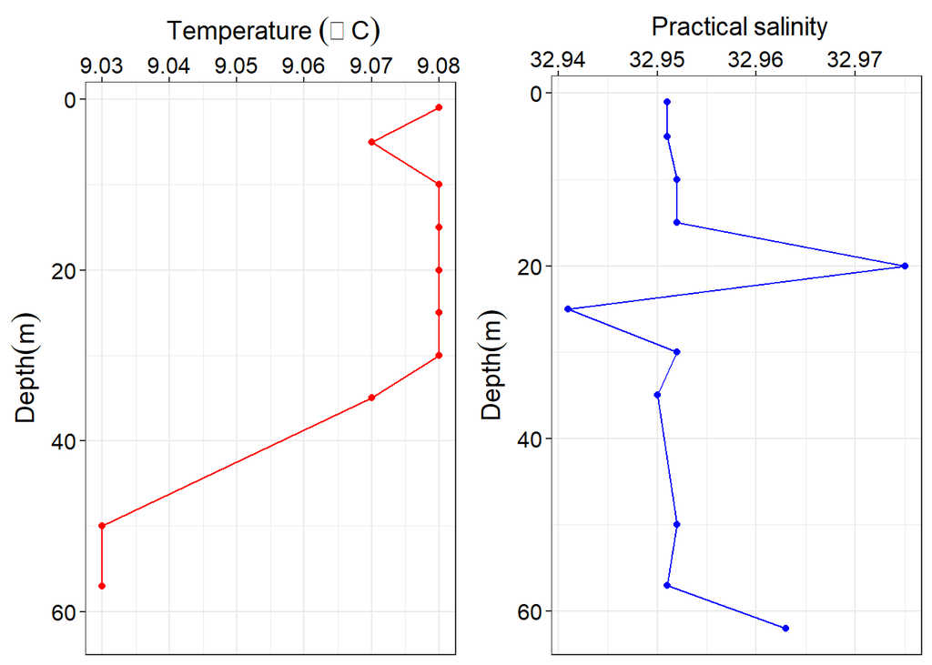

```r
# sort(unique(ctd.80$cruise_id)) # this ctd does not have a matching cruise_id
# to larval data, closest is AL8010, but the lat lon are different
#AL8010 <- subset(ctd.80, cruise_id == 'ALB8010') # 35.6833, -74.95
DEL8003<- subset(ctd.80, cruise_id == 'DEL8003')
ev.471 <- subset(larv.80, cruise_id == "AL8010") # 38.9833, -73.1333
# lat lon 40.85,-68.7333
coords <- which(DEL8003$latitude == 40.85 & DEL8003$longitude == -68.7333)
DEL8003.c111 = DEL8003[coords,]

temp = ggplot(DEL8003.c111,
              aes(x = (sea_water_temperature),
                  y = (depth))) +
  geom_point(color = 'red') +
  geom_path(col = 'red') +
  scale_x_continuous(position = "top") +
  scale_y_reverse() +
  theme_bw() +
  theme(axis.text = element_text(size = 12, colour = 1),
        axis.title = element_text(size = 14, colour = 1))+
  labs(x = expression(~Temperature~(degree~C)),
      y = expression(Depth (m)))
sal =  ggplot(DEL8003.c111,
              aes(x = (sea_water_salinity),
                  y = (depth))) +
  geom_point(color = 'blue') +
  geom_path(col = 'blue') +
  scale_x_continuous(position = "top")+
  scale_y_reverse() +
  theme_bw() +
  theme(axis.text = element_text(size = 12, colour = 1),
        axis.title = element_text(size = 14, colour = 1))+
  labs(x = expression(~Practical~salinity),
       y = expression(Depth (m)))

cowplot::plot_grid(temp,sal, nrow = 1)
```

Cruise id = EVR8004, Cast 115 (42.3167,-67.7833) Bottom depth 220, gear type = bottle

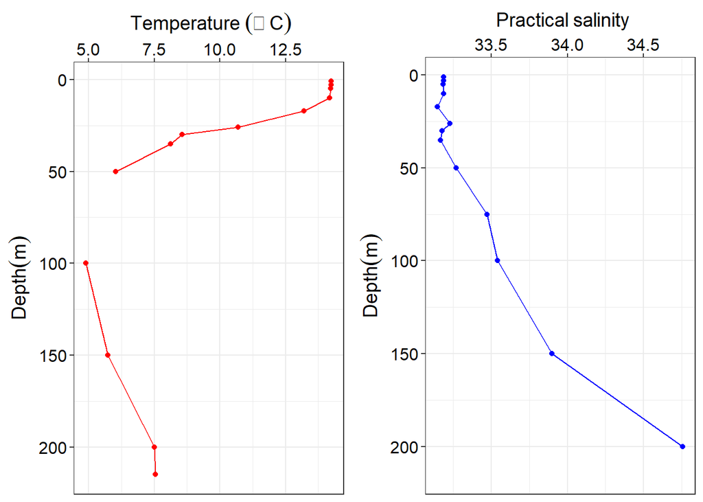

```r
EVR8004 <- subset(ctd.80, cruise_id == 'EVR8004')
# lat lon 42.3167,-67.7833
coords <- which(EVR8004$latitude == 42.3167 & EVR8004$longitude == -67.7833)
EVR8004.c130 = EVR8004[coords,]

temp = ggplot(EVR8004.c130,
              aes(x = (sea_water_temperature),
                  y = (depth))) +
  geom_point(color = 'red') +
  geom_path(col = 'red') +
  scale_x_continuous(position = "top") +
  scale_y_reverse() +
  theme_bw() +
  theme(axis.text = element_text(size = 12, colour = 1),
        axis.title = element_text(size = 14, colour = 1))+
  labs(x = expression(~Temperature~(degree~C)),
      y = expression(Depth (m)))
sal =  ggplot(EVR8004.c130,
              aes(x = (sea_water_salinity),
                  y = (depth))) +
  geom_point(color = 'blue') +
  geom_path(col = 'blue') +
  scale_x_continuous(position = "top")+
  scale_y_reverse() +
  theme_bw() +
  theme(axis.text = element_text(size = 12, colour = 1),
        axis.title = element_text(size = 14, colour = 1))+
  labs(x = expression(~Practical~salinity),
       y = expression(Depth (m)))

cowplot::plot_grid(temp,sal, nrow = 1)
```

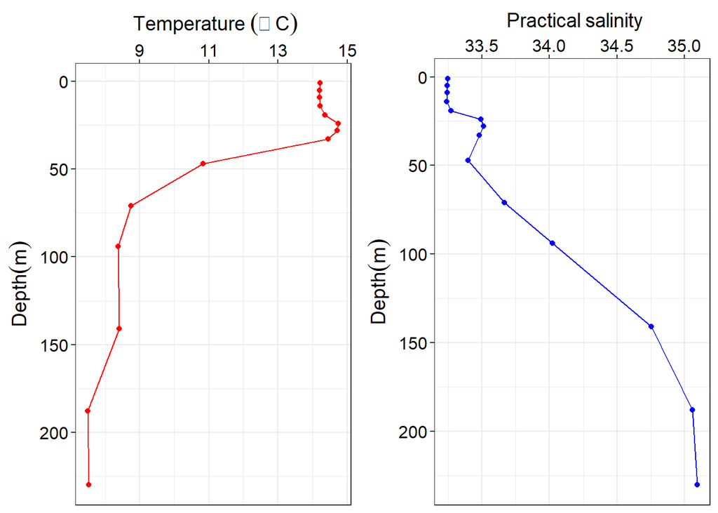

```r
ALB8010 <- subset(ctd.80, cruise_id == 'ALB8010')

# lat lon 40.1667, -70.7667
coords <- which(ALB8010$latitude == 42.4667 & ALB8010$longitude == -66.3333)
ALB8010.c81 = ALB8010[coords,]

temp = ggplot(ALB8010.c81,
              aes(x = (sea_water_temperature),
                  y = (depth))) +
  geom_point(color = 'red') +
  geom_path(col = 'red') +
  scale_x_continuous(position = "top") +
  scale_y_reverse() +
  theme_bw() +
  theme(axis.text = element_text(size = 12, colour = 1),
        axis.title = element_text(size = 14, colour = 1))+
  labs(x = expression(~Temperature~(degree~C)),
      y = expression(Depth (m)))
sal =  ggplot(ALB8010.c81,
              aes(x = (sea_water_salinity),
                  y = (depth))) +
  geom_point(color = 'blue') +
  geom_path(col = 'blue') +
  scale_x_continuous(position = "top")+
  scale_y_reverse() +
  theme_bw() +
  theme(axis.text = element_text(size = 12, colour = 1),
        axis.title = element_text(size = 14, colour = 1))+
  labs(x = expression(~Practical~salinity),
       y = expression(Depth (m)))

cowplot::plot_grid(temp,sal, nrow = 1)
```

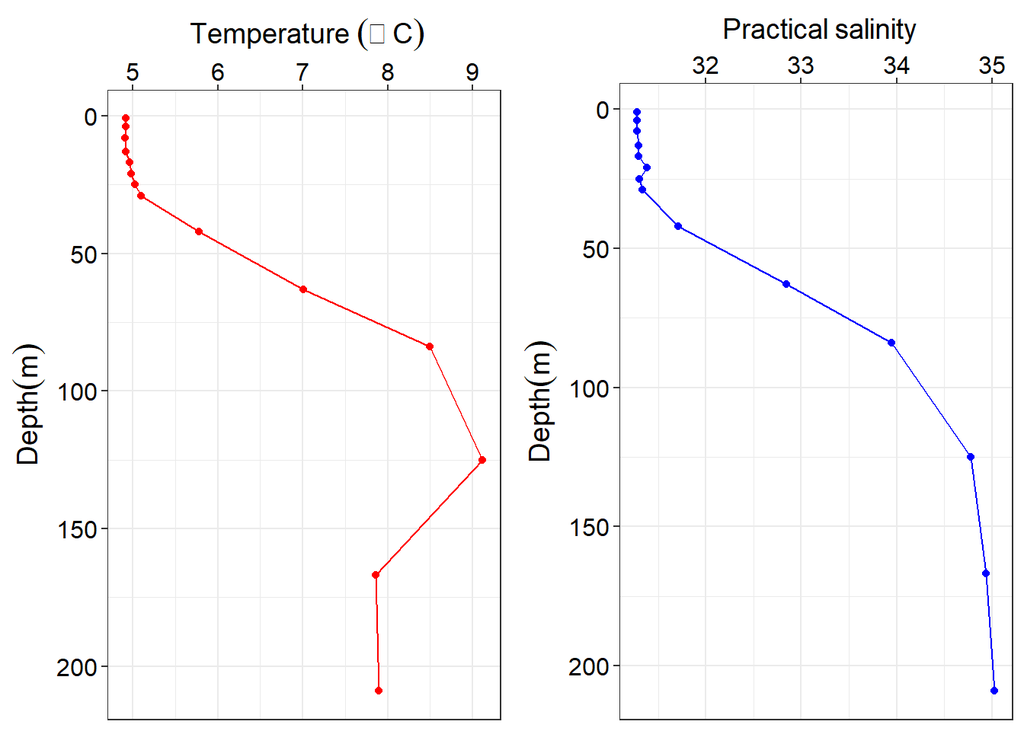

```r
ALB8012 <- subset(ctd.80, cruise_id == 'ALB8012')

# lat lon (42.4667,-66.3333)
coords <- which(ALB8012$latitude == 42.4667 & ALB8012$longitude == -66.3333)
ALB8012.c135 = ALB8012[coords,]

temp = ggplot(ALB8012.c135,
              aes(x = (sea_water_temperature),
                  y = (depth))) +
  geom_point(color = 'red') +
  geom_path(col = 'red') +
  scale_x_continuous(position = "top") +
  scale_y_reverse() +
  theme_bw() +
  theme(axis.text = element_text(size = 12, colour = 1),
        axis.title = element_text(size = 14, colour = 1))+
  labs(x = expression(~Temperature~(degree~C)),
      y = expression(Depth (m)))
sal =  ggplot(ALB8012.c135,
              aes(x = (sea_water_salinity),
                  y = (depth))) +
  geom_point(color = 'blue') +
  geom_path(col = 'blue') +
  scale_x_continuous(position = "top")+
  scale_y_reverse() +
  theme_bw() +
  theme(axis.text = element_text(size = 12, colour = 1),
        axis.title = element_text(size = 14, colour = 1))+
  labs(x = expression(~Practical~salinity),
       y = expression(Depth (m)))

cowplot::plot_grid(temp,sal, nrow = 1)
```